# IA en SHS : promesses, preuves, limites

Semaine DATA‑SHS 2025, Maison des Sciences de l’Homme (MSH), Clermont‑Ferrand

Pierre Beaucoral, CERDI (UCA, CNRS, IRD)

2025-12-12

# Définition

## Origines de “L’IA”

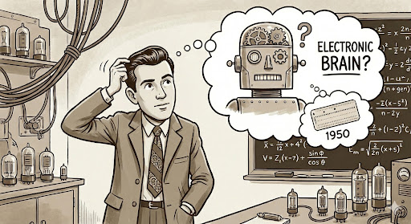

Crédits: Gemini (Nano Banana Pro)

> Cette image est sensée représenter Alan Turing, “père de l’IA” (TURING 1950)

## Utilisation de l’IA aujourd’hui

[figure not shown]

Panorama des familles d’IA

[figure not shown]

Crédits: Gemini (Nano Banana Pro)

> Expression de Bender et al. (2021)

# Promesses: pourquoi l’IA séduit

- Échelle Corpus massifs (textes, images, rasters, graphes) → nouvelles variables analytiques.
- Vitesse Pré‑analyse, tri, résumé, extraction; meilleure compréhension?
- Hétérogénéités, sous‑groupes; policy learning (arbres/règles lisibles).

## Finalement, qu’est ce que ça change?

- Augmente le champ des possibles:
  - nouveaux outils
  - nouvelles données
  - nouvelles preuves

# Preuves

Exemples basés sur mes recherches:

- Doctorant en économie
- Aide au développement et Aide climatique

Je vais utiliser ici:

- Analyse de texte
- Analyse de données satellitaires

## IA pour classifier

[figure not shown]

## Classifier pour mieux estimer

[figure not shown]

## Estimer pour décrire

[figure not shown]

## Décrire pour comparer

[figure not shown]

## Comparer pour mettre en lumière les causes

[figure not shown]

## Mettre en lumière pour recommander

[figure not shown]

## Quels apports?

- Automatisation: gain de temps; standardisation; replication
- Nouvelles données: classifications alternatives; création
- Nouvelles réponses à des questions de recherche existantes

## Autres exemples

- **Archives** : OCR + NLP pour structurer débats/sources; audit d’erreurs systématiques
- **Histoire** (KANSTEINER 2022)
- **Analyse littéraire** (S and V 2024)
- Analyse qualitative (Christou 2023)

# Limites

## biais et angles morts

- **Données** : langues, régions sous‑représentées, périodes, jargons hétérogènes. *Est-ce vraiment différent des travaux d’analyse pre-IA?*
- **Modèles** : Résultats variants et n’étant pas fixes.
- **Analyse spatiale** : erreurs écologiques; risque de ré‑identification par croisements; qualité de la donnée. *Encore, est-ce vraiment différent?*
- Quand l’IA influence le practicien: Vicente and Matute (2023)

## Six gestes de fiabilité: pratiques concrètes

1. Déclarer le rôle exact de l’IA
2. Documenter le pipeline
3. Tester les performances du modèle sur des sous groupes définis
4. Faire un audit humain ciblé
5. Tester la robustesse par alternatives
6. Séparer prédiction et explication

# Merci de votre attention

- Contact : pierre.beaucoral@uca.fr

# Références

Bender, Emily M., Timnit Gebru, Angelina McMillan-Major, and Shmargaret Shmitchell. 2021. “On the Dangers of Stochastic Parrots.” *Proceedings of the 2021 ACM Conference on Fairness, Accountability, and Transparency*, March, 610–23. https://doi.org/10.1145/3442188.3445922.

Christou, Prokopis. 2023. “Ηow to Use Artificial Intelligence (AI) as a Resource, Methodological and Analysis Tool in Qualitative Research?” *The Qualitative Report*, July. https://doi.org/10.46743/2160-3715/2023.6406.

KANSTEINER, WULF. 2022. “DIGITAL DOPING FOR HISTORIANS: CAN HISTORY, MEMORY, AND HISTORICAL THEORY BE RENDERED ARTIFICIALLY INTELLIGENT?” *History and Theory* 61 (4): 119–33. https://doi.org/10.1111/hith.12282.

S, Vinodini, and Adithya Pothan Raj V. 2024. “Enhancing Literary Analysis Through Artificial Intelligence and Machine Learning: Insights from ’the Alchemist’.” *2024 2nd International Conference on Recent Advances in Information Technology for Sustainable Development (ICRAIS)*, November, 136–41. https://doi.org/10.1109/icrais62903.2024.10811737.

TURING, A. M. 1950. “I.COMPUTING MACHINERY AND INTELLIGENCE.” *Mind* LIX (236): 433–60. https://doi.org/10.1093/mind/lix.236.433.

Vicente, Lucía, and Helena Matute. 2023. “Humans Inherit Artificial Intelligence Biases.” *Scientific Reports* 13 (1). https://doi.org/10.1038/s41598-023-42384-8.